# UFC Fight Analysis

# Multivariate Analysis

Now that we have an overview of the variables involved, let's take a look at some of the interactions.

## Strikes vs Win Percentage

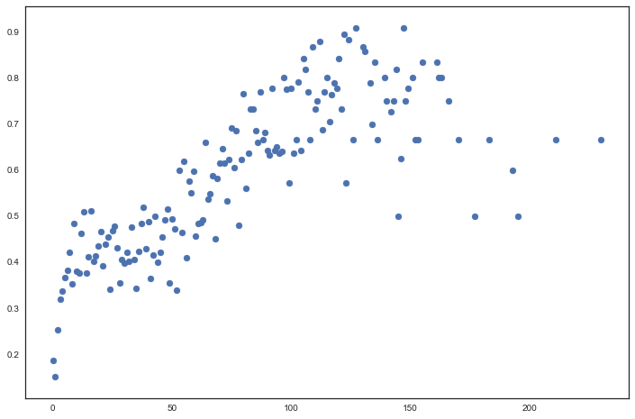

```python
strike_wins = fight_df.loc[fight_df.outcome == 1, 'strikes'].value_counts()
strike_losses = fight_df.loc[fight_df.outcome == 0, 'strikes'].value_counts()
strike_overall = pd.concat([strike_wins, strike_losses], join="inner", axis=1)
strike_overall.columns = ['wins', 'losses']
strike_overall.win_perc = strike_overall.wins / (strike_overall.wins + strike_overall.losses)

plt.figure(figsize = (12,8))
plt.scatter(strike_overall.index, strike_overall.win_perc)
plt.xlabel('Strikes')
plt.ylabel('Win Probability')
plt.show()
```

# Data Cleaning

The first step in data cleaning is to remove obvious outliers and columns that will not contribute to the model. We've already dropped no contests, DQ's and draws. Let's check other areas. Here's a list of ideas so far:

1. Create accuracy percentages where appropriate
2. Keep a running tally of each fighter's record (wins/losses)

## Logical Errors

Now that the missing values have been taken care of, it might be a good idea to check for any logical errors. Any situations where strikes landed > strikes attempted, takedowns > takedown attempts, etc should be looked at carefully. Let's run a short script to see if any of the above situations are present.

```python
a_cols = [
    u'body_attempts', u'clinch_attempts', u'distance_attempts',
    u'ground_attempts', u'head_attempts', u'leg_attempts', u'sig_attempts',
    u'strike_attempts', u'td_attempts'
]

l_cols = [
    u'body', u'clinch', u'distance', u'ground', u'head', u'leg', u'sig_strikes',
    u'strikes', u'takedowns'
]

for attempts, landed in zip(a_cols, l_cols):
    print attempts
    print fight_df[fight_df[attempts]<fight_df[landed]][[attempts,landed]]
```

```
body_attempts
Empty DataFrame
Columns: [body_attempts, body]
Index: []
clinch_attempts
Empty DataFrame
Columns: [clinch_attempts, clinch]
Index: []
distance_attempts
Empty DataFrame
Columns: [distance_attempts, distance]
Index: []
ground_attempts
Empty DataFrame
Columns: [ground_attempts, ground]
Index: []
head_attempts
Empty DataFrame
Columns: [head_attempts, head]
Index: []
leg_attempts
Empty DataFrame
Columns: [leg_attempts, leg]
Index: []
sig_attempts
Empty DataFrame
Columns: [sig_attempts, sig_strikes]
Index: []
strike_attempts
Empty DataFrame
Columns: [strike_attempts, strikes]
Index: []
td_attempts
Empty DataFrame
Columns: [td_attempts, takedowns]
Index: []
```

Looks good, all output columns are empty as expected.

# Feature Engineering

What is it about each figher that makes him a favorite? This may require a lot or rearranging, so it may be worth it to think this through a bit first. I could reset each fighter's stats and only add stats that came prior to each fight. This would be a more comprehensive way of comparing each fighter and would align more closely to real-world applications. Here's a rough sketch of what the process might look like:

1. Add columns for kicks taken, punches taken, etc?
   1. One disadvantage is that this would mean nearly doubling the number of variables in a dataset that is already massive. This will hurt some machine learning models. Let's omit this for now and come back to it later if necessary.

## Comparing Winners and Losers

Next, I will create a running tally of differences between each fighter in each fight. My hope is that by comparing the winners and losers of each individual fight, I might be able to determine which features, if any can predict success in the UFC.

I will look at both ratios and differences, but I want to start with differences first. Right off the bat, I can see that the ratio strategy will come with its own set of challenges because of the number of values that are equal to zero. It may be possible to add one to all relevant columns to overcome this, but I want to tackle the easier problem first.

The following script sorts the dataframe by id and then by win/loss so that the fight loser is always presented first.

```python
fight_df.sort_values(['fight_id', 'win/loss'], inplace=True)
fight_df.index = range(len(fight_df))
len(fight_df[(fight_df['win/loss']=='W') & (fight_df.index%2==0)])
```

```
0
```

The losing fighters are now presented first, which will make the process of separating winners and losers slightly easier.

### Fighter Differences

```python
cols = [u'body', u'body_attempts', u'clinch', u'clinch_attempts', u'distance',
       u'distance_attempts', u'ground', u'ground_attempts',
       u'head', u'head_attempts', u'knockdowns', u'leg', u'leg_attempts',
       u'pass', u'reversals', u'sig_attempts', u'sig_strikes',
       u'strike_attempts', u'strikes', u'sub_attempts', u'takedowns',
       u'td_attempts']

fighter_a = fight_df[fight_df.index%2==0]
fighter_b = fight_df[fight_df.index%2==1]

fighter_a.reset_index(inplace=True, drop=True)
fighter_b.reset_index(inplace=True, drop=True)

fight_loser_diff = fighter_a.copy()
fight_winner_diff = fighter_b.copy()

fight_loser_ratio = fighter_a.copy()
fight_winner_ratio = fighter_b.copy()

fight_loser_diff.loc[:, cols] = fighter_a[cols] - fighter_b[cols]
fight_winner_diff.loc[:, cols] = fighter_b[cols] - fighter_a[cols]
```

```python
fight_loser_diff.head()
```

|  | name | date | fight_id | win/loss | method | body | body_attempts | clinch | clinch_attempts | distance | distance_attempts | ground | ground_attempts | head | head_attempts | knockdowns | leg | leg_attempts | location | pass | referee | reversals | round | sig_attempts | sig_strikes | strike_attempts | strikes | sub_attempts | takedowns | … |
| --- | --- | --- | --- | --- | --- | --- | --- | --- | --- | --- | --- | --- | --- | --- | --- | --- | --- | --- | --- | --- | --- | --- | --- | --- | --- | --- | --- | --- | --- | --- |
| 0 | Teila Tuli | 1993-11-12 | 0 | L | KO/TKO | 0 | 0 | 0 | 0 | -1 | -2 | -2 | -2 | -3 | -4 | 0 | 0 | 0 | Denver, Colorado, USA | 0 | Joao Barreto | 0 | 1 | -4 | -3 | -4 | -3 | 0 | 0 | … |
| 1 | Zane Frazier | 1993-11-12 | 1 | L | KO/TKO | 0 | 2 | 6 | 10 | -4 | -3 | -5 | -6 | -5 | -4 | -2 | 2 | 3 | Denver, Colorado, USA | 0 | Joao Barreto | 0 | 1 | 1 | -3 | -24 | -25 | 0 | 0 | … |
| 2 | Art Jimmerson | 1993-11-12 | 2 | L | Submission | 0 | 0 | 0 | 0 | 0 | -3 | 0 | 0 | 0 | -1 | 0 | 0 | -2 | Denver, Colorado, USA | -2 | Joao Barreto | 0 | 1 | -3 | 0 | -7 | -4 | 0 | -1 | … |
| 3 | Patrick Smith | 1993-11-12 | 3 | L | Submission | 1 | 1 | 1 | 1 | 1 | 1 | 1 | 5 | 0 | 3 | 0 | 2 | 3 | Denver, Colorado, USA | 0 | Joao Barreto | 0 | 1 | 7 | 3 | 16 | 12 | -2 | -1 | … |
| 4 | Kevin Rosier | 1993-11-12 | 4 | L | KO/TKO | -1 | 0 | 0 | 0 | -5 | -5 | -6 | -9 | -7 | -12 | -1 | -3 | -2 | Denver, Colorado, USA | 0 | Joao Barreto | 0 | 1 | -14 | -11 | -14 | -11 | 0 | 0 | … |

```python
fight_winner_diff.head()
```

|  | name | date | fight_id | win/loss | method | body | body_attempts | clinch | clinch_attempts | distance | distance_attempts | ground | ground_attempts | head | head_attempts | knockdowns | leg | leg_attempts | location | pass | referee | reversals | round | sig_attempts | sig_strikes | strike_attempts | strikes | sub_attempts | takedowns | … |
| --- | --- | --- | --- | --- | --- | --- | --- | --- | --- | --- | --- | --- | --- | --- | --- | --- | --- | --- | --- | --- | --- | --- | --- | --- | --- | --- | --- | --- | --- | --- |
| 0 | Gerard Gordeau | 1993-11-12 | 0 | W | KO/TKO | 0 | 0 | 0 | 0 | 1 | 2 | 2 | 2 | 3 | 4 | 0 | 0 | 0 | Denver, Colorado, USA | 0 | Joao Barreto | 0 | 1 | 4 | 3 | 4 | 3 | 0 | 0 | … |
| 1 | Kevin Rosier | 1993-11-12 | 1 | W | KO/TKO | 0 | -2 | -6 | -10 | 4 | 3 | 5 | 6 | 5 | 4 | 2 | -2 | -3 | Denver, Colorado, USA | 0 | Joao Barreto | 0 | 1 | -1 | 3 | 24 | 25 | 0 | 0 | … |
| 2 | Royce Gracie | 1993-11-12 | 2 | W | Submission | 0 | 0 | 0 | 0 | 0 | 3 | 0 | 0 | 0 | 1 | 0 | 0 | 2 | Denver, Colorado, USA | 2 | Joao Barreto | 0 | 1 | 3 | 0 | 7 | 4 | 0 | 1 | … |
| 3 | Ken Shamrock | 1993-11-12 | 3 | W | Submission | -1 | -1 | -1 | -1 | -1 | -1 | -1 | -5 | 0 | -3 | 0 | -2 | -3 | Denver, Colorado, USA | 0 | Joao Barreto | 0 | 1 | -7 | -3 | -16 | -12 | 2 | 1 | … |
| 4 | Gerard Gordeau | 1993-11-12 | 4 | W | KO/TKO | 1 | 0 | 0 | 0 | 5 | 5 | 6 | 9 | 7 | 12 | 1 | 3 | 2 | Denver, Colorado, USA | 0 | Joao Barreto | 0 | 1 | 14 | 11 | 14 | 11 | 0 | 0 | … |

```python
fight_diffs = pd.concat(
    [fight_winner_diff,fight_loser_diff],
    ignore_index=True
    )
```

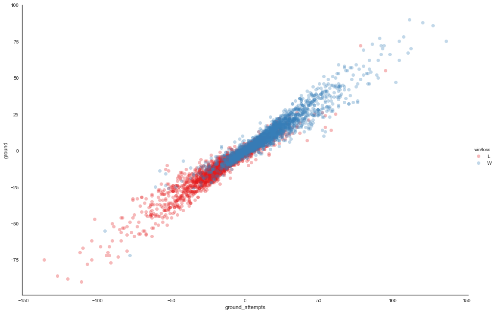

```python
sns.lmplot(
    'ground_attempts',
    'ground',
    data=fight_diffs[::-1],
    hue='win/loss',
    palette='Set1',
    scatter_kws={'alpha':.3},
    fit_reg=False,
    size=9,
    aspect=1.5
)
plt.show()
```

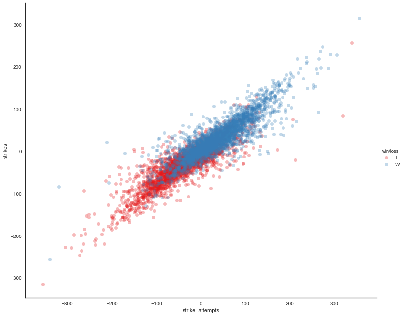

```python
sns.lmplot(
    'strike_attempts',
    'strikes',
    data=fight_diffs[::-1],
    hue='win/loss',
    palette='Set1',
    scatter_kws={'alpha':.3},
    fit_reg=False,
    size=9,
    aspect=1.2
)
plt.show()
```

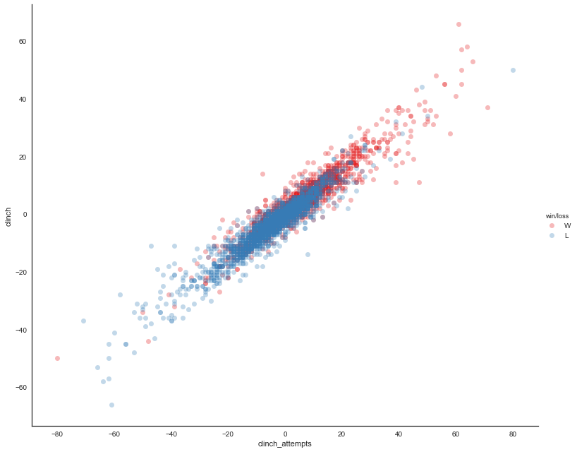

```python
sns.lmplot(
    'clinch_attempts',
    'clinch',
    data=fight_diffs,
    hue='win/loss',
    palette='Set1',
    scatter_kws={'alpha':.3},
    fit_reg=False,
    size=9,
    aspect=1.2
)
plt.show()
```

### Fighter Log Differences

```python
fighter_a_logs = fighter_a.copy()
fighter_a_logs.loc[:, cols] = fighter_a[cols] + 1
fighter_a_logs.loc[:, cols] = fighter_a_logs[cols].apply(np.log)

fighter_b_logs = fighter_b.copy()
fighter_b_logs.loc[:, cols] = fighter_b[cols] + 1
fighter_b_logs.loc[:, cols] = fighter_b_logs[cols].apply(np.log)


fight_loser_log_diffs = fighter_a_logs.copy()
fight_winner_log_diffs = fighter_b_logs.copy()

fight_loser_log_diffs.loc[:, cols] = fighter_a_logs[cols] - fighter_b_logs[cols]
fight_winner_log_diffs.loc[:, cols] = fighter_b_logs[cols] - fighter_a_logs[cols]


fight_loser_log_diffs.head()
```

|  | name | date | fight_id | win/loss | method | body | body_attempts | clinch | clinch_attempts | distance | distance_attempts | ground | ground_attempts | head | head_attempts | knockdowns | leg | leg_attempts | location | pass | referee | reversals | round | sig_attempts | sig_strikes | strike_attempts | strikes | sub_attempts | takedowns | … |
| --- | --- | --- | --- | --- | --- | --- | --- | --- | --- | --- | --- | --- | --- | --- | --- | --- | --- | --- | --- | --- | --- | --- | --- | --- | --- | --- | --- | --- | --- | --- |
| 0 | Teila Tuli | 1993-11-12 | 0 | L | KO/TKO | 0.000000 | 0.000000 | 0.000000 | 0.000000 | -0.693147 | -0.693147 | -1.098612 | -1.098612 | -1.386294 | -1.098612 | 0.000000 | 0.000000 | 0.000000 | Denver, Colorado, USA | 0.000000 | Joao Barreto | 0.0 | 1 | -1.098612 | -1.386294 | -1.098612 | -1.386294 | 0.000000 | 0.000000 | … |
| 1 | Zane Frazier | 1993-11-12 | 1 | L | KO/TKO | 0.000000 | 0.336472 | 0.788457 | 0.693147 | -1.609438 | -0.318454 | -0.980829 | -1.098612 | -0.485508 | -0.182322 | -1.098612 | 1.098612 | 1.386294 | Denver, Colorado, USA | 0.000000 | Joao Barreto | 0.0 | 1 | 0.035091 | -0.207639 | -0.587787 | -1.024504 | 0.000000 | 0.000000 | … |
| 2 | Art Jimmerson | 1993-11-12 | 2 | L | Submission | 0.000000 | 0.000000 | 0.000000 | 0.000000 | 0.000000 | -1.386294 | 0.000000 | 0.000000 | 0.000000 | -0.693147 | 0.000000 | 0.000000 | -1.098612 | Denver, Colorado, USA | -1.098612 | Joao Barreto | 0.0 | 1 | -1.386294 | 0.000000 | -2.079442 | -1.609438 | 0.000000 | -0.693147 | … |
| 3 | Patrick Smith | 1993-11-12 | 3 | L | Submission | 0.693147 | 0.693147 | 0.693147 | 0.693147 | 0.693147 | 0.693147 | 0.405465 | 1.252763 | 0.000000 | 0.916291 | 0.000000 | 1.098612 | 1.386294 | Denver, Colorado, USA | 0.000000 | Joao Barreto | 0.0 | 1 | 1.504077 | 0.916291 | 1.435085 | 1.223775 | -1.098612 | -0.693147 | … |
| 4 | Kevin Rosier | 1993-11-12 | 4 | L | KO/TKO | -0.693147 | 0.000000 | 0.000000 | 0.000000 | -1.791759 | -0.810930 | -1.945910 | -2.302585 | -2.079442 | -1.945910 | -0.693147 | -1.386294 | -0.693147 | Denver, Colorado, USA | 0.000000 | Joao Barreto | 0.0 | 1 | -1.504077 | -2.484907 | -1.504077 | -2.484907 | 0.000000 | 0.000000 | … |

```python
fight_winner_log_diffs.head()
```

|  | name | date | fight_id | win/loss | method | body | body_attempts | clinch | clinch_attempts | distance | distance_attempts | ground | ground_attempts | head | head_attempts | knockdowns | leg | leg_attempts | location | pass | referee | reversals | round | sig_attempts | sig_strikes | strike_attempts | strikes | sub_attempts | takedowns | … |
| --- | --- | --- | --- | --- | --- | --- | --- | --- | --- | --- | --- | --- | --- | --- | --- | --- | --- | --- | --- | --- | --- | --- | --- | --- | --- | --- | --- | --- | --- | --- |
| 0 | Gerard Gordeau | 1993-11-12 | 0 | W | KO/TKO | 0.000000 | 0.000000 | 0.000000 | 0.000000 | 0.693147 | 0.693147 | 1.098612 | 1.098612 | 1.386294 | 1.098612 | 0.000000 | 0.000000 | 0.000000 | Denver, Colorado, USA | 0.000000 | Joao Barreto | 0.0 | 1 | 1.098612 | 1.386294 | 1.098612 | 1.386294 | 0.000000 | 0.000000 | … |
| 1 | Kevin Rosier | 1993-11-12 | 1 | W | KO/TKO | 0.000000 | -0.336472 | -0.788457 | -0.693147 | 1.609438 | 0.318454 | 0.980829 | 1.098612 | 0.485508 | 0.182322 | 1.098612 | -1.098612 | -1.386294 | Denver, Colorado, USA | 0.000000 | Joao Barreto | 0.0 | 1 | -0.035091 | 0.207639 | 0.587787 | 1.024504 | 0.000000 | 0.000000 | … |
| 2 | Royce Gracie | 1993-11-12 | 2 | W | Submission | 0.000000 | 0.000000 | 0.000000 | 0.000000 | 0.000000 | 1.386294 | 0.000000 | 0.000000 | 0.000000 | 0.693147 | 0.000000 | 0.000000 | 1.098612 | Denver, Colorado, USA | 1.098612 | Joao Barreto | 0.0 | 1 | 1.386294 | 0.000000 | 2.079442 | 1.609438 | 0.000000 | 0.693147 | … |
| 3 | Ken Shamrock | 1993-11-12 | 3 | W | Submission | -0.693147 | -0.693147 | -0.693147 | -0.693147 | -0.693147 | -0.693147 | -0.405465 | -1.252763 | 0.000000 | -0.916291 | 0.000000 | -1.098612 | -1.386294 | Denver, Colorado, USA | 0.000000 | Joao Barreto | 0.0 | 1 | -1.504077 | -0.916291 | -1.435085 | -1.223775 | 1.098612 | 0.693147 | … |
| 4 | Gerard Gordeau | 1993-11-12 | 4 | W | KO/TKO | 0.693147 | 0.000000 | 0.000000 | 0.000000 | 1.791759 | 0.810930 | 1.945910 | 2.302585 | 2.079442 | 1.945910 | 0.693147 | 1.386294 | 0.693147 | Denver, Colorado, USA | 0.000000 | Joao Barreto | 0.0 | 1 | 1.504077 | 2.484907 | 1.504077 | 2.484907 | 0.000000 | 0.000000 | … |

```python
fight_log_diffs = pd.concat(
    [fight_loser_log_diffs, fight_winner_log_diffs,],
    ignore_index=True
    )
```

### Fighter Ratios

```python
'''
fighter_a.loc[:, cols] += 1
fighter_b.loc[:, cols] += 1

fight_loser_ratio.loc[:, cols] = fighter_a[cols] / fighter_b[cols]
fight_winner_ratio.loc[:, cols] = fighter_b[cols] / fighter_a[cols]
'''
```

```python
# fight_winner_ratio.head()
```

```python
# fight_loser_ratio.head()
```

```python
'''
fight_ratios = pd.concat(
    [fight_winner_ratio,fight_loser_ratio],
    ignore_index=True
    )
'''
```

### Running Tallies

The next step is to get a running tally of each fighter's stats and compare them to his or her opponent. Let's break this down:

1. How are you going to do this for each row? Will you loop through or use some sort of apply function?
2. You only want to affect certain columns.

```python
fight_copy = fight_df.copy()
for i in range(1,len(fight_copy)):
    cur_name = fight_df.loc[i, 'name']
    prev_fights = fight_df.iloc[:i]
    fight_copy.loc[i, cols] = np.mean(prev_fights.loc[prev_fights.name == cur_name, cols])
```

```python
fight_copy = fight_copy.iloc[1:]
test_copy = fight_copy.copy()
```

Now that you have a running tally, the next step is to exclude all fights where one of the fighters is making their debut.

```python
for i in test_copy.fight_id.tolist():
    f1 = test_copy[(test_copy.fight_id == i) & (test_copy.outcome == 1)]
    f2 = test_copy[(test_copy.fight_id == i) & (test_copy.outcome == 0)]
    if sum(f1.isnull().any().values) or sum(f2.isnull().any().values):
        test_copy = test_copy[test_copy.fight_id != i]

test_copy
fight_tallies = test_copy.copy()
```

The next step is to subtract the differences between each fighter, then take the log difference. Fortunately, we have the code for that!

#### Differences

```python
fight_tallies.reset_index(inplace=True, drop=True)
```

```python
fighter_x = fight_tallies[fight_tallies.index%2==0]
fighter_y = fight_tallies[fight_tallies.index%2==1]

fighter_x.reset_index(inplace=True, drop=True)
fighter_y.reset_index(inplace=True, drop=True)

tally_loser_diff = fighter_x.copy()
tally_winner_diff = fighter_y.copy()

tally_loser_diff.loc[:, cols] = fighter_x[cols] - fighter_y[cols]
tally_winner_diff.loc[:, cols] = fighter_y[cols] - fighter_x[cols]
```

```python
tally_diffs = pd.concat(
    [tally_loser_diff, tally_winner_diff],
    ignore_index=True
    )
```

#### Log Differences

```python
fighter_x_logs = fighter_x.copy()
fighter_x_logs.loc[:, cols] = fighter_x[cols] + 1
fighter_x_logs.loc[:, cols] = fighter_x_logs[cols].apply(np.log)

fighter_y_logs = fighter_y.copy()
fighter_y_logs.loc[:, cols] = fighter_y[cols] + 1
fighter_y_logs.loc[:, cols] = fighter_y_logs[cols].apply(np.log)


tally_loser_log_diffs = fighter_x_logs.copy()
tally_winner_log_diffs = fighter_y_logs.copy()

tally_loser_log_diffs.loc[:, cols] = fighter_x_logs[cols] - fighter_y_logs[cols]
tally_winner_log_diffs.loc[:, cols] = fighter_y_logs[cols] - fighter_x_logs[cols]


tally_loser_log_diffs.head()
```

|  | name | date | fight_id | win/loss | method | body | body_attempts | clinch | clinch_attempts | distance | distance_attempts | ground | ground_attempts | head | head_attempts | knockdowns | leg | leg_attempts | location | pass | referee | reversals | round | sig_attempts | sig_strikes | strike_attempts | strikes | sub_attempts | takedowns | … |
| --- | --- | --- | --- | --- | --- | --- | --- | --- | --- | --- | --- | --- | --- | --- | --- | --- | --- | --- | --- | --- | --- | --- | --- | --- | --- | --- | --- | --- | --- | --- |
| 0 | Kevin Rosier | 1993-11-12 | 4 | L | KO/TKO | 1.386294 | 1.609438 | 1.609438 | 2.302585 | 0.916291 | 1.011601 | 0.980829 | 1.098612 | 1.178655 | 1.386294 | 1.098612 | 0.000000 | 0.000000 | Denver, Colorado, USA | 0.000000 | Joao Barreto | 0.000000 | 1 | 1.540445 | 1.386294 | 2.197225 | 2.277267 | 0.000000 | 0.000000 | … |
| 1 | Ken Shamrock | 1993-11-12 | 5 | L | Submission | 0.000000 | 0.000000 | 0.000000 | 0.000000 | 0.000000 | -1.386294 | 0.693147 | 0.693147 | 0.693147 | 0.000000 | 0.000000 | 0.000000 | -1.098612 | Denver, Colorado, USA | -1.098612 | Joao Barreto | 0.000000 | 1 | -0.693147 | 0.693147 | -0.470004 | 0.000000 | 1.098612 | 0.000000 | … |
| 2 | Gerard Gordeau | 1993-11-12 | 7 | L | Submission | 0.405465 | 0.405465 | 0.000000 | 0.000000 | 1.386294 | 0.955511 | 1.609438 | 1.871802 | 1.791759 | 1.897120 | 0.405465 | 0.916291 | 0.223144 | Denver, Colorado, USA | -1.098612 | Joao Barreto | -0.405465 | 1 | 1.568616 | 2.079442 | 0.133531 | -0.117783 | -0.405465 | -0.405465 | … |
| 3 | Scott Morris | 1994-03-11 | 16 | L | KO/TKO | -0.693147 | -0.693147 | 0.000000 | 0.000000 | -0.405465 | -0.405465 | -0.693147 | -1.386294 | 0.287682 | -0.405465 | 0.000000 | -0.693147 | -0.916291 | Denver, Colorado, USA | 0.693147 | John McCarthy | 0.000000 | 1 | -1.011601 | -0.559616 | -1.343735 | -1.152680 | 0.287682 | 0.693147 | … |
| 4 | Orlando Wiet | 1994-03-11 | 18 | L | KO/TKO | 0.693147 | 0.693147 | 0.000000 | 0.000000 | 0.693147 | 0.693147 | 0.470004 | 0.510826 | 0.470004 | 0.693147 | 0.000000 | 0.000000 | -0.693147 | Denver, Colorado, USA | -1.098612 | John McCarthy | 0.000000 | 1 | 0.619039 | 0.587787 | -0.362905 | -0.559616 | -0.693147 | -0.693147 | … |

```python
tally_log_diffs = pd.concat(
    [tally_loser_log_diffs, tally_winner_log_diffs,],
    ignore_index=True
    )
```

# Modeling

We're going to be methodical when building and testing our algorithms. It's easy to run in circles due to the plethora of algorithms and parameters available. Is a decision tree a better choice? Or should we try Random Forest? What about Support Vector Machines? The machines need our support! Rather than going through all these possibilities and forgetting the results, we'll build pipelines and document our process as we go along. By staying organized, it will be easier to tell if we've already tried a solution. It may also serve to highlight the desired path a bit (one can only hope).

Here's a list of models we have so far. We may add to this list, but it's a good starting place.

1. Perceptron
2. Random Forests
3. Decision Trees Classifier
4. SGD Classifier
5. Linear SVC
6. Gaussian NB
7. KNN

Of course, machine learning isn't just about finding that perfect algorithm. The results depend heavily on earlier steps in the process. One might even say that most of the accuracy depends on the exploratory analysis and feature engineering. That's why so much time was spent in that phase.

Now that we have a few algorithms to explore, we'll pay close attention to each one's hyperparameters. If the data is unbalanced, we'll need to account for that and if it's overfitting / underfitting, we may have to make a different set of changes. There's a lot to absorb here. Let's take our time and keep in mind that data analysis is not a linear process. Sometimes we have to go back and forth between modeling, wrangling, exploring and feature engineering. We can't be afraid to get our hands dirty!

## Extracting Features and Labels

### Numerical Differences

```python
numerical_diffs = fight_diffs.select_dtypes(include=[np.int64])
numerical_diffs = numerical_diffs.drop(['fight_id', 'round'], axis=1)
```

```python
numerical_diffs.head()
```

|  | body | body_attempts | clinch | clinch_attempts | distance | distance_attempts | ground | ground_attempts | head | head_attempts | knockdowns | leg | leg_attempts | pass | reversals | sig_attempts | sig_strikes | strike_attempts | strikes | sub_attempts | takedowns | td_attempts | outcome |
| --- | --- | --- | --- | --- | --- | --- | --- | --- | --- | --- | --- | --- | --- | --- | --- | --- | --- | --- | --- | --- | --- | --- | --- |
| 0 | 0 | 0 | 0 | 0 | 1 | 2 | 2 | 2 | 3 | 4 | 0 | 0 | 0 | 0 | 0 | 4 | 3 | 4 | 3 | 0 | 0 | -1 | 1 |
| 1 | 0 | -2 | -6 | -10 | 4 | 3 | 5 | 6 | 5 | 4 | 2 | -2 | -3 | 0 | 0 | -1 | 3 | 24 | 25 | 0 | 0 | 0 | 1 |
| 2 | 0 | 0 | 0 | 0 | 0 | 3 | 0 | 0 | 0 | 1 | 0 | 0 | 2 | 2 | 0 | 3 | 0 | 7 | 4 | 0 | 1 | 1 | 1 |
| 3 | -1 | -1 | -1 | -1 | -1 | -1 | -1 | -5 | 0 | -3 | 0 | -2 | -3 | 0 | 0 | -7 | -3 | -16 | -12 | 2 | 1 | 2 | 1 |
| 4 | 1 | 0 | 0 | 0 | 5 | 5 | 6 | 9 | 7 | 12 | 1 | 3 | 2 | 0 | 0 | 14 | 11 | 14 | 11 | 0 | 0 | 0 | 1 |

### Log Differences

```python
numerical_log_diffs = fight_log_diffs.select_dtypes(include=[np.int64, np.float])
numerical_log_diffs = numerical_log_diffs.drop(['fight_id', 'round'], axis=1)
```

```python
numerical_log_diffs.head()
```

|  | body | body_attempts | clinch | clinch_attempts | distance | distance_attempts | ground | ground_attempts | head | head_attempts | knockdowns | leg | leg_attempts | pass | reversals | sig_attempts | sig_strikes | strike_attempts | strikes | sub_attempts | takedowns | td_attempts | outcome |
| --- | --- | --- | --- | --- | --- | --- | --- | --- | --- | --- | --- | --- | --- | --- | --- | --- | --- | --- | --- | --- | --- | --- | --- |
| 0 | 0.000000 | 0.000000 | 0.000000 | 0.000000 | -0.693147 | -0.693147 | -1.098612 | -1.098612 | -1.386294 | -1.098612 | 0.000000 | 0.000000 | 0.000000 | 0.000000 | 0.0 | -1.098612 | -1.386294 | -1.098612 | -1.386294 | 0.000000 | 0.000000 | 0.693147 | 0 |
| 1 | 0.000000 | 0.336472 | 0.788457 | 0.693147 | -1.609438 | -0.318454 | -0.980829 | -1.098612 | -0.485508 | -0.182322 | -1.098612 | 1.098612 | 1.386294 | 0.000000 | 0.0 | 0.035091 | -0.207639 | -0.587787 | -1.024504 | 0.000000 | 0.000000 | 0.000000 | 0 |
| 2 | 0.000000 | 0.000000 | 0.000000 | 0.000000 | 0.000000 | -1.386294 | 0.000000 | 0.000000 | 0.000000 | -0.693147 | 0.000000 | 0.000000 | -1.098612 | -1.098612 | 0.0 | -1.386294 | 0.000000 | -2.079442 | -1.609438 | 0.000000 | -0.693147 | -0.693147 | 0 |
| 3 | 0.693147 | 0.693147 | 0.693147 | 0.693147 | 0.693147 | 0.693147 | 0.405465 | 1.252763 | 0.000000 | 0.916291 | 0.000000 | 1.098612 | 1.386294 | 0.000000 | 0.0 | 1.504077 | 0.916291 | 1.435085 | 1.223775 | -1.098612 | -0.693147 | -1.098612 | 0 |
| 4 | -0.693147 | 0.000000 | 0.000000 | 0.000000 | -1.791759 | -0.810930 | -1.945910 | -2.302585 | -2.079442 | -1.945910 | -0.693147 | -1.386294 | -0.693147 | 0.000000 | 0.0 | -1.504077 | -2.484907 | -1.504077 | -2.484907 | 0.000000 | 0.000000 | 0.000000 | 0 |

### Tally Differences

```python
numerical_tally_diffs = tally_diffs.select_dtypes(include=[np.int64, np.float])
numerical_tally_diffs = numerical_tally_diffs.drop(['fight_id', 'round'], axis=1)
```

### Tally Log Differences

```python
numerical_tally_log_diffs = tally_log_diffs.select_dtypes(include=[np.int64, np.float])
numerical_tally_log_diffs = numerical_tally_log_diffs.drop(['fight_id', 'round'], axis=1)
```

## Models

```python
# We store the prediction of each model in our dict
# Also included helper functions for each model

def percep(X_train,Y_train,X_test,Y_test,Models):
    perceptron = Perceptron(max_iter = 1000, tol = 0.001, random_state=42)
    perceptron.fit(X_train, Y_train)
    Y_pred = perceptron.predict(X_test)
    Models['Perceptron'] = [
        accuracy_score(Y_test,Y_pred),
        precision_score(Y_test, Y_pred),
        recall_score(Y_test, Y_pred),
        confusion_matrix(Y_test,Y_pred),
    ]
    return

def ranfor(X_train,Y_train,X_test,Y_test,Models):
    randomfor = RandomForestClassifier(max_features="sqrt",
                                       n_estimators = 700,
                                       max_depth = None,
                                       n_jobs=-1,
                                       random_state=42
                                      )
    randomfor.fit(X_train,Y_train)
    Y_pred = randomfor.predict(X_test)
    Models['Random Forests'] = [
        accuracy_score(Y_test,Y_pred),
        precision_score(Y_test, Y_pred),
        recall_score(Y_test, Y_pred),
        confusion_matrix(Y_test,Y_pred),
    ]
    return

def dec_tree(X_train,Y_train,X_test,Y_test,Models):
    decision_tree = DecisionTreeClassifier(random_state=42)
    decision_tree.fit(X_train, Y_train)
    Y_pred = decision_tree.predict(X_test)
    Models['Decision Tree'] = [
        accuracy_score(Y_test,Y_pred),
        precision_score(Y_test, Y_pred),
        recall_score(Y_test, Y_pred),
        confusion_matrix(Y_test,Y_pred),
    ]
    return

def SGDClass(X_train,Y_train,X_test,Y_test,Models):
    sgd = SGDClassifier(max_iter = 1000, tol = 0.001, random_state=42)
    sgd.fit(X_train, Y_train)
    Y_pred = sgd.predict(X_test)
    Models['SGD Classifier'] = [
        accuracy_score(Y_test,Y_pred),
        precision_score(Y_test, Y_pred),
        recall_score(Y_test, Y_pred),
        confusion_matrix(Y_test,Y_pred),
    ]
    return

def linSVC(X_train,Y_train,X_test,Y_test,Models):
    linear_svc = LinearSVC(random_state=42)
    linear_svc.fit(X_train, Y_train)
    Y_pred = linear_svc.predict(X_test)
    Models['SVM'] = [
        accuracy_score(Y_test,Y_pred),
        precision_score(Y_test, Y_pred),
        recall_score(Y_test, Y_pred),
        confusion_matrix(Y_test,Y_pred),
    ]
    return

def bayes(X_train,Y_train,X_test,Y_test,Models):
    gaussian = GaussianNB()
    gaussian.fit(X_train, Y_train)
    Y_pred = gaussian.predict(X_test)
    Models['Bayes'] = [
        accuracy_score(Y_test,Y_pred),
        precision_score(Y_test, Y_pred),
        recall_score(Y_test, Y_pred),
        confusion_matrix(Y_test,Y_pred),
    ]
    return

def Nearest(X_train,Y_train,X_test,Y_test,Models):
    knn = KNeighborsClassifier(n_neighbors = 3)
    knn.fit(X_train, Y_train)
    Y_pred = knn.predict(X_test)
    Models['KNN'] = [
        accuracy_score(Y_test,Y_pred),
        precision_score(Y_test, Y_pred),
        recall_score(Y_test, Y_pred),
        confusion_matrix(Y_test,Y_pred),
    ]

def run_all_and_Plot(df):
    Models = dict()
    from sklearn.model_selection import train_test_split
    #X_all = df.drop(['win/loss'], axis=1)
    #y_all = df['win/loss']
    X_all = df.drop(['outcome'], axis=1)
    y_all = df['outcome']
    X_train, X_test, Y_train, Y_test = train_test_split(X_all, y_all, test_size=0.2, random_state=42)
    percep(X_train,Y_train,X_test,Y_test,Models)
    ranfor(X_train,Y_train,X_test,Y_test,Models)
    dec_tree(X_train,Y_train,X_test,Y_test,Models)
    SGDClass(X_train,Y_train,X_test,Y_test,Models)
    linSVC(X_train,Y_train,X_test,Y_test,Models)
    bayes(X_train,Y_train,X_test,Y_test,Models)
    Nearest(X_train,Y_train,X_test,Y_test,Models)
    return Models


def plot_bar(dict, i):
    titles = ['Accuracy', 'Precision', 'Recall']
    labels = tuple(dict.keys())
    y_pos = np.arange(len(labels))
    values = [dict[n][i] for n in dict]
    plt.bar(y_pos, values, align='center', alpha=0.5)
    plt.xticks(y_pos, labels,rotation='vertical')
    plt.ylabel(titles[i])
    plt.title('{} of different models'.format(titles[i]))
    plt.show()


def plot_cm(dict):
    count = 1
    fig = plt.figure(figsize=(10,10))
    for model in dict:
        cm = dict[model][3]
        labels = ['W','L']
        ax = fig.add_subplot(4,4,count)
        cax = ax.matshow(cm)
        plt.title(model,y=-0.8)
        fig.colorbar(cax)
        ax.set_xticklabels([''] + labels)
        ax.set_yticklabels([''] + labels)
        plt.xlabel('Predicted')
        plt.ylabel('True')
        # plt.subplot(2,2,count)
        count+=1
    plt.tight_layout()
    plt.show()
```

```
KNN 0.804142011834
SVM 0.826035502959
Decision Tree 0.81775147929
Random Forests 0.872189349112
SGD Classifier 0.866863905325
Bayes 0.830769230769
Perceptron 0.857396449704
```

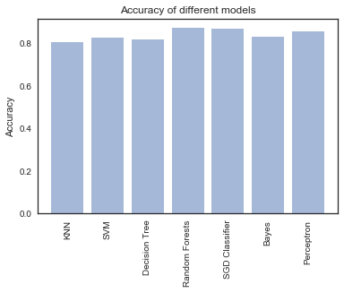

```
KNN 0.797219003476
SVM 0.828947368421
Decision Tree 0.817535545024
Random Forests 0.870283018868
SGD Classifier 0.862837045721
Bayes 0.836956521739
Perceptron 0.85428907168
```

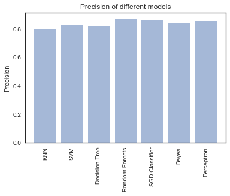

```
KNN 0.815165876777
SVM 0.821090047393
Decision Tree 0.817535545024
Random Forests 0.874407582938
SGD Classifier 0.872037914692
Bayes 0.821090047393
Perceptron 0.861374407583
```

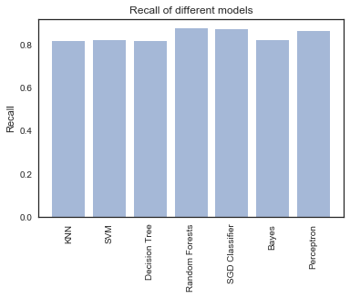

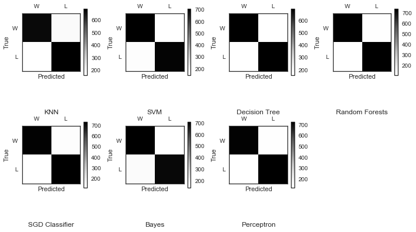

```python
score_metrics = run_all_and_Plot(numerical_diffs)
CompareAll = dict()
CompareAll['Baseline'] = score_metrics

for i in range(3):
    for key,val in score_metrics.items():
        print(str(key) +' '+ str(val[i]))
    plot_bar(score_metrics, i)

plot_cm(score_metrics)
```

```
KNN 0.814792899408
SVM 0.862130177515
Decision Tree 0.804142011834
Random Forests 0.862130177515
SGD Classifier 0.841420118343
Bayes 0.824852071006
Perceptron 0.776923076923
```

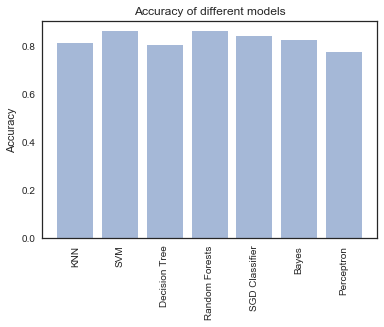

```
KNN 0.809523809524
SVM 0.858479532164
Decision Tree 0.810615199035
Random Forests 0.861012956419
SGD Classifier 0.840801886792
Bayes 0.820512820513
Perceptron 0.745036572623
```

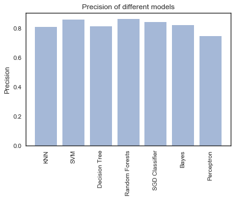

```
KNN 0.823877068558
SVM 0.867612293144
Decision Tree 0.794326241135
Random Forests 0.864066193853
SGD Classifier 0.842789598109
Bayes 0.832151300236
Perceptron 0.842789598109
```

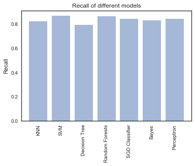

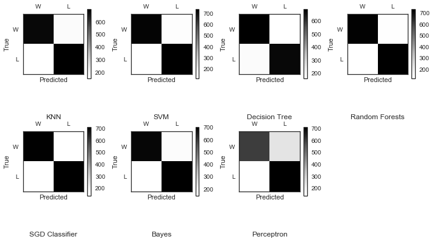

```python
score_metrics = run_all_and_Plot(numerical_log_diffs)
for i in range(3):
    for key,val in score_metrics.items():
        print(str(key) +' '+ str(val[i]))
    plot_bar(score_metrics, i)
plot_cm(score_metrics)
```

```
KNN 0.539316239316
SVM 0.524786324786
Decision Tree 0.526495726496
Random Forests 0.526495726496
SGD Classifier 0.464957264957
Bayes 0.565811965812
Perceptron 0.464102564103
```

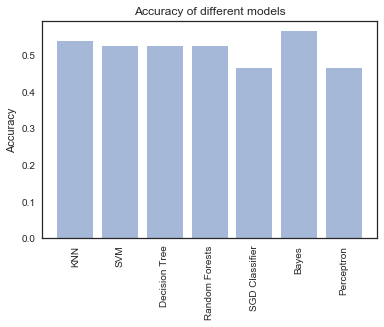

```
KNN 0.526495726496
SVM 0.51198630137
Decision Tree 0.513698630137
Random Forests 0.513605442177
SGD Classifier 0.453020134228
Bayes 0.55
Perceptron 0.451939291737
```

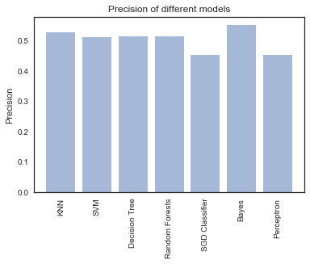

```
KNN 0.540350877193
SVM 0.524561403509
Decision Tree 0.526315789474
Random Forests 0.529824561404
SGD Classifier 0.473684210526
Bayes 0.598245614035
Perceptron 0.470175438596
```

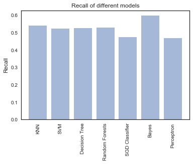

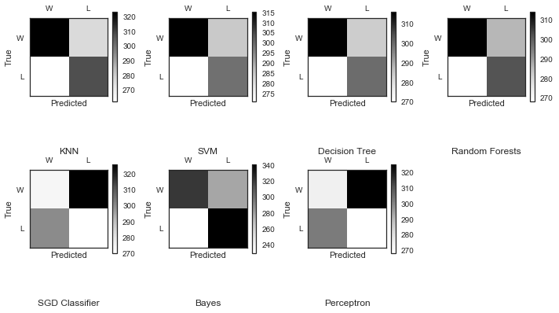

```python
score_metrics = run_all_and_Plot(numerical_tally_diffs)
for i in range(3):
    for key,val in score_metrics.items():
        print(str(key) +' '+ str(val[i]))
    plot_bar(score_metrics, i)
plot_cm(score_metrics)
```

```
KNN 0.520512820513
SVM 0.582051282051
Decision Tree 0.512820512821
Random Forests 0.532478632479
SGD Classifier 0.562393162393
Bayes 0.558974358974
Perceptron 0.52735042735
```

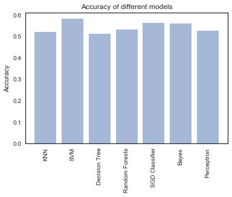

```
KNN 0.50736497545
SVM 0.568296795953
Decision Tree 0.5
Random Forests 0.519861830743
SGD Classifier 0.551971326165
Bayes 0.546391752577
Perceptron 0.514285714286
```

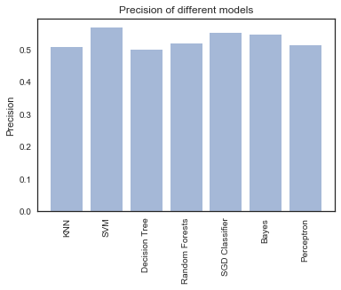

```
KNN 0.543859649123
SVM 0.591228070175
Decision Tree 0.5
Random Forests 0.528070175439
SGD Classifier 0.540350877193
Bayes 0.557894736842
Perceptron 0.536842105263
```

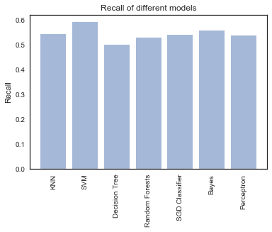

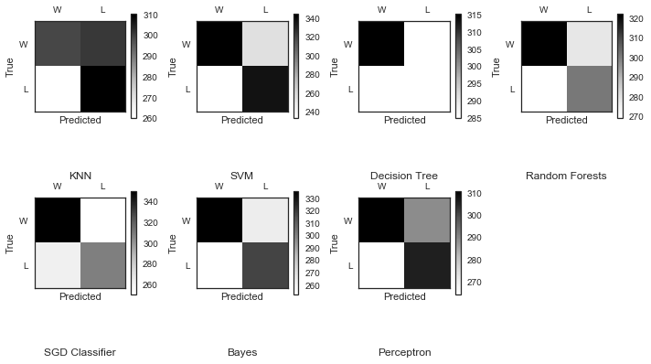

```python
score_metrics = run_all_and_Plot(numerical_tally_log_diffs)
for i in range(3):
    for key,val in score_metrics.items():
        print(str(key) +' '+ str(val[i]))
    plot_bar(score_metrics, i)
plot_cm(score_metrics)
```

## Predicting UFC 216

It might be fun testing out the classifier on current fight cards. I'll have to do some refactoring, but it'll be a great way to benchmark my progress.

```python
names = [
    "Tony Ferguson", "Kevin Lee", "Demetrious Johnson", "Ray Borg", "Derrick Lewis",
    "Fabricio Werdum", "Mara Romero Borella", "Kalindra Faria", "Beneil Dariush",
    "Evan Dunham", "Tom Duquesnoy", "Cody Stamann", "Bobby Green", "Lando Vannata",
    "Poliana Botelho", "Pearl Gonzalez", "Mark Godbeer", "Walt Harris",
    "Magomed Bibulatov", "John Moraga", "Thales Leites", "Brad Tavares",
    "Marco Beltran", "Matt Schnell"
        ]
for name in names:
    print len(tally_log_diffs[tally_log_diffs.name == name])
```

```
11
10
13
4
9
11
0
0
10
15
0
0
6
2
0
0
0
5
0
8
15
12
3
1
```

[output not shown]

```python
from sklearn.model_selection import train_test_split

x_all = numerical_diffs.drop(['outcome'], axis=1)
y_all = numerical_diffs['outcome']
x_train, x_test, y_train, y_test = train_test_split(x_all, y_all, test_size=0.2, random_state=0)
```

```
Accuracy Score: 0.878698224852
```

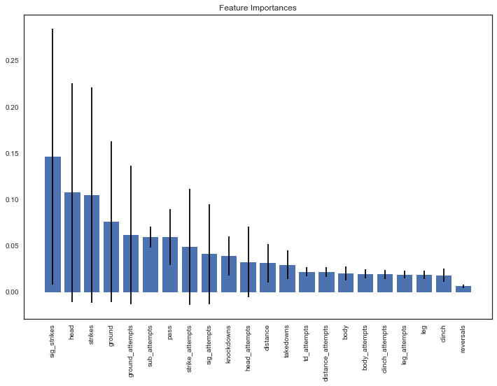

```python
forest = RandomForestClassifier(max_features="sqrt",
                                       n_estimators = 700,
                                       max_depth = None,
                                       n_jobs=-1,
                                       random_state=42
                                      )
forest.fit(x_train,y_train)
importances = forest.feature_importances_
indices = np.argsort(importances)[::-1]
std = np.std([tree.feature_importances_ for tree in forest.estimators_],
             axis=0)
labels = list(numerical_log_diffs.columns)

y_pred = forest.predict(x_test)
print "Accuracy Score:", accuracy_score(y_test,y_pred)

plt.figure(figsize=(12,8))
plt.title("Feature Importances")
plt.bar(
    range(len(numerical_log_diffs.columns)-1),
    importances[indices],
    align="center",
    yerr = std[indices]
)
plt.xticks(
    range(len(numerical_log_diffs.columns)),
    [labels[i] for i in indices],
    rotation='vertical'
)
plt.show()
```

```python
from sklearn.model_selection import train_test_split

x_all = numerical_tally_diffs.drop(['outcome'], axis=1)
y_all = numerical_tally_diffs['outcome']
x_train, x_test, y_train, y_test = train_test_split(x_all, y_all, test_size=0.2, random_state=0)
```

```
Accuracy Score: 0.554700854701
```

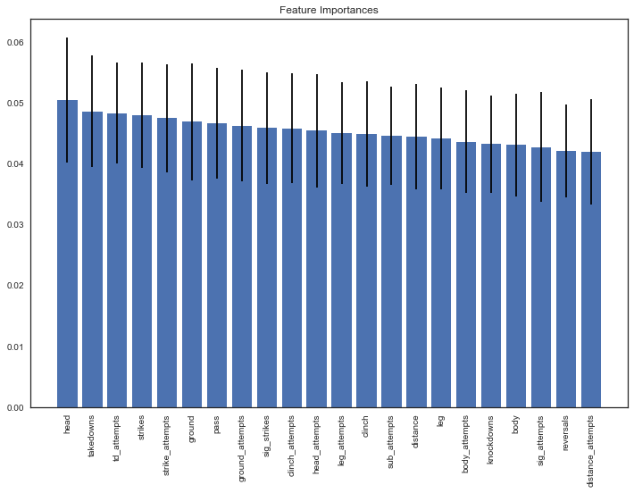

```python
forest = RandomForestClassifier(max_features="sqrt",
                                       n_estimators = 700,
                                       max_depth = None,
                                       n_jobs=-1,
                                       random_state=42
                                      )
forest.fit(x_train,y_train)
importances = forest.feature_importances_
indices = np.argsort(importances)[::-1]
std = np.std([tree.feature_importances_ for tree in forest.estimators_],
             axis=0)
labels = list(numerical_log_diffs.columns)

y_pred = forest.predict(x_test)
print "Accuracy Score:", accuracy_score(y_test,y_pred)

plt.figure(figsize=(12,8))
plt.title("Feature Importances")
plt.bar(
    range(len(numerical_log_diffs.columns)-1),
    importances[indices],
    align="center",
    yerr = std[indices]
)
plt.xticks(
    range(len(numerical_log_diffs.columns)),
    [labels[i] for i in indices],
    rotation='vertical'
)
plt.show()
```

```python
from sklearn.model_selection import train_test_split, GridSearchCV
#X_all = dropdata.drop(['winner'], axis=1)
#y_all = dropdata['winner']
#X_train, X_test, Y_train, Y_test = train_test_split(X_all, y_all, test_size=0.2, random_state=23)
#rfc = RandomForestClassifier(n_jobs=-1,max_features= 'sqrt' ,n_estimators=50, oob_score = True, max_depth=None)
#param_grid = {
#    'n_estimators': [200,700],
#    'max_features': ['auto', 'sqrt', 'log2']
#}

#CV_rfc = GridSearchCV(estimator=rfc, param_grid=param_grid, cv= 5)
#CV_rfc.fit(X_train, Y_train)
#print(CV_rfc.best_params_)
```

## Reducing Features

# Stretch Goals

## Get Probability of a Win

Once this first part is done, it would be nice to calculate the probability that a fighter will win his/her next match.

# Scraper Rewrite

The fightmetric scraper reached completion a couple days ago with added functionality. Initially, I scraped the fights in one large chunk, but this had several drawbacks: it took hours to get any results, there was no way to tell whether it was pulling data properly and when it crashed, it resulted in a loss of all data (omg losing all progress after a script has been running for 3 hours is maddening!). The new iteration runs the scraper in chunks in a separate jupyter notebook. Each script processes 200 lines of fight urls and saves the results to separate CSVs. Enabled `runtools` in `nbextensions` to add the `run all cells ignore errors` option. This prevents the whole process from stoping if there's an error in one of the cells. This is a design principal I'm going to hold onto for future large projects because it prevents a lot of headaches.

## Data Enhancement

The following features have been added:

1. Date
2. Location
3. Title
4. Proper Name
5. Proper Win/Loss

## Bugs

1. Data is missing sometimes.
   1. Want to debug to determine why different runs yield different amounts of data
   2. Update: after fixing the name, last few runs have yielded a consistent number of rows (8774).

## Pull requests

1. Details: This holds information on how the fight was finished (punches to head, neck crank, etc)
   1. Code it up if time and run at night

# Todo

1. Graph several variables:
   1. Counts with sns.barplot
   2. Counts with plt.plot
   3. Violin plot of one variable over several categories
   4. sns.distplot of numerical variable
   5. Look at round data
   6. Heatmap
   7. Wordcloud of referee names
   8. Jointplot of two variables
2. Create percentages column for each landed / attempted statistic
3. Aggregate all data so it's ongoing
   1. Sum each fighter's data to make it possible to compare fighters in a reasonable way
   2. One idea is to subtract two fighters' non-ratio stats and use them as labels
   3. You can still use ratio stats as labels
4. Rewrite models to account for the unbalanced data.
   1. Most fights are won by decision, so that should be accounted for
5. Add visuals

# Ideas

1. Classifier for current fight is working. Need to re-think a way to get the prediction algorithm to work as well. Maybe getting more information on the fighters:
   1. Birth year
   2. Training camp
   3. Years training
   4. Background / specialty (boxing, wrestling bjj, etc)
2. Need to re-think how the data is fed into the prediction model. Doing tally differences is not currently working. Need to tweak that idea:
   1. Current trajectory?
   2. Only last few fights?
   3. Average fight statistics against other fighters?
   4. This would take the differences between their stats and opponents' stats in each previous fight and average them